# Modelling point-level space-time data - An application using ozone concentrations in New York

Bayesian modelling for spatial and spatio-temporal data

Week 10

In this tutorial we use a dataset that comprises daily maximum 8-hour average ground level ozone (O$_3$, ppb) concentrations for the period July 1 and August 31 in 2006, measured at 28 monitoring sites in the state of New York, USA. The stations are part of the Environmental Protection Agency (EPA) monitoring network. Ozone occurs naturally in the upper atmosphere and protects the Earth from the sun’s rays. However, at ground level it can be harmful for population health, as it can lead to adverse respiratory effects. Ozone is most likely to reach worrisome levels on hot sunny days in urban environments (even so it can still reach high levels during colder months).  
Ozone is one of the “criteria pollutants” regularly monitored by the US EPA.

The dataset used for this tutorial is included in the packages `spBayes` and `spTimer`. Today we will use the package `spTimer` by Bakar and Sahu (2015) to model ozone concentrations in New York state. This package is exclusively devoted to fitting and prediction for point-referenced spatio-temporal data. The paper by Bakar and Sahu (2015) uses this dataset for demonstration. Here we follow their analysis.

The data available are as follows:

- `s.index`: index of the monitoring station in the NY state
- `Longitude` and `Latitude`: spatial coordinates of the monitoring stations
- `Year`, `Month` and `Day`: temporal coordinates of the measurement
- `o8hrmax`: daily 8-hour maximum average ozone concentrations (parts per billion)
- `cMAXTMP`: maximum temperature (in degree Celsius)
- `WDSP`: wind speed (knots),
- `RH`: percentage average relative humidity

We use `o8hrmax` concentrations as outcome and `cMAXTMP`, `WDSP`, and `RH` as predictors.

# Before starting the tutorial

- Create a separate directory in your home directory to save your files created during this tutorial.
- Copy all the files from the blackboard to your directory (created just above).
- If not installed yet, then install the R packages required for this tutorial

```r
install.packages(c("lubridate","spTimer","dplyr" ,"coda", "ggmcmc","mcmcplots","GGally","leaflet","mvtsplot", "maps","MBA", "fields","colorspace","corrr","knitr", "kableExtra"), type = "both",
dependencies = TRUE, repos = c(CRAN = "http://cran.r-project.org"))
```

- Load needed libraries:

```r
library(lubridate)    # tools to work with date-time data
library(dplyr)        # tools data manipulations
library(spTimer)      # package for point-referenced spatio-temporal data
library(coda)         # tools for convergence diagnostics
library(ggmcmc)       # tools for MCMC diagnostics using ggplot
# library(mcmcplots)  # tolls for MCMC diagnostics
library(GGally)       # tools for plots (extend functionality of
                      # ggplot2)
library(mapview)      # interactive maps
library(corrr)        # tools for exploring correlations
library(mvtsplot)     # function for plotting multivariate time series
                      # data
library(maps)         # display of maps
library(MBA)          # functions to interpolate irregularly and
                      # regularly spaced data
library(fields)       # tools for Spatial Data
library(colorspace)   # toolbox for colors or color palettes

# For tables in RMarkdown
library(knitr)
library(kableExtra)
```

# The New York dataset: visualization, manipulation and explorative analysis

The data are obtained from 28 monitoring sites, between July 1 and August 31 in 2006.

- Load the data in `R`

```r
data(NYdata)
```

- Now, we print the data, formatting these in a table.

```r
kable(head(NYdata),
      caption = "The first 6 rows of New York dataset") %>%
kable_styling(bootstrap_options = "striped", full_width = F, position = "center")
```

The first 6 rows of New York dataset

| s.index | Longitude | Latitude | Year | Month | Day | o8hrmax | cMAXTMP | WDSP | RH |
| --- | --- | --- | --- | --- | --- | --- | --- | --- | --- |
| 1 | -73.757 | 42.681 | 2006 | 7 | 1 | 53.88 | 27.85772 | 5.459953 | 2.766221 |
| 1 | -73.757 | 42.681 | 2006 | 7 | 2 | 57.13 | 30.11563 | 8.211767 | 3.197750 |
| 1 | -73.757 | 42.681 | 2006 | 7 | 3 | 72.00 | 30.00001 | 4.459581 | 3.225186 |
| 1 | -73.757 | 42.681 | 2006 | 7 | 4 | 36.63 | 27.89656 | 3.692225 | 4.362334 |
| 1 | -73.757 | 42.681 | 2006 | 7 | 5 | 42.63 | 25.65698 | 4.374314 | 3.950320 |
| 1 | -73.757 | 42.681 | 2006 | 7 | 6 | 30.88 | 24.61968 | 4.178086 | 3.420533 |

```r
# Print the data
NYdata[1:6,] %>%
  kbl(caption = "The first 6 rows of New York dataset") %>%
  kable_classic(full_width = F, html_font = "Cambria")
```

The first 6 rows of New York dataset

| s.index | Longitude | Latitude | Year | Month | Day | o8hrmax | cMAXTMP | WDSP | RH |
| --- | --- | --- | --- | --- | --- | --- | --- | --- | --- |
| 1 | -73.757 | 42.681 | 2006 | 7 | 1 | 53.88 | 27.85772 | 5.459953 | 2.766221 |
| 1 | -73.757 | 42.681 | 2006 | 7 | 2 | 57.13 | 30.11563 | 8.211767 | 3.197750 |
| 1 | -73.757 | 42.681 | 2006 | 7 | 3 | 72.00 | 30.00001 | 4.459581 | 3.225186 |
| 1 | -73.757 | 42.681 | 2006 | 7 | 4 | 36.63 | 27.89656 | 3.692225 | 4.362334 |
| 1 | -73.757 | 42.681 | 2006 | 7 | 5 | 42.63 | 25.65698 | 4.374314 | 3.950320 |
| 1 | -73.757 | 42.681 | 2006 | 7 | 6 | 30.88 | 24.61968 | 4.178086 | 3.420533 |

```r
stations <- cbind(unique(NYdata[,1]), unique(NYdata[,2:3]))

# set the map projection to a common projection standard such as WGS84 via the argument crs = 4326
mapview(stations, xcol = "Longitude", ycol = "Latitude", crs = 4269, grid = FALSE)
```

[interactive chart not shown]

- We create a variable `date` using the package `lubridate`, which is part of the core `tidyverse`.

```r
NYdata <- NYdata %>%
  mutate(date = make_date(Year, Month, Day))
```

- We now plot the concentrations of ozone for each monitoring station using the package `mvtsplot`, which allows the visualization of Multivariate time Series (Link: http://www.biostat.jhsph.edu/~rpeng/RR/mvtsplot/). To be able to use it, we need to convert the data from long to wide format.

```r
# select ozone data
O3 <- NYdata %>% select(s.index, o8hrmax, date)
dim(O3) #1736    3
```

```
## [1] 1736    3
```

```r
O3_wide = O3 %>%
  spread(s.index, o8hrmax)
dim(O3_wide) #62 29
```

```
## [1] 62 29
```

```r
O3_wide <- O3_wide[,-1] # remove date
O3_wide <- data.matrix(O3_wide)
dim(O3_wide)
```

```
## [1] 62 28
```

```r
colnames(O3_wide) <- unique(O3[,1])
```

And now plot the ozone concentrations for the 28 monitoring stations

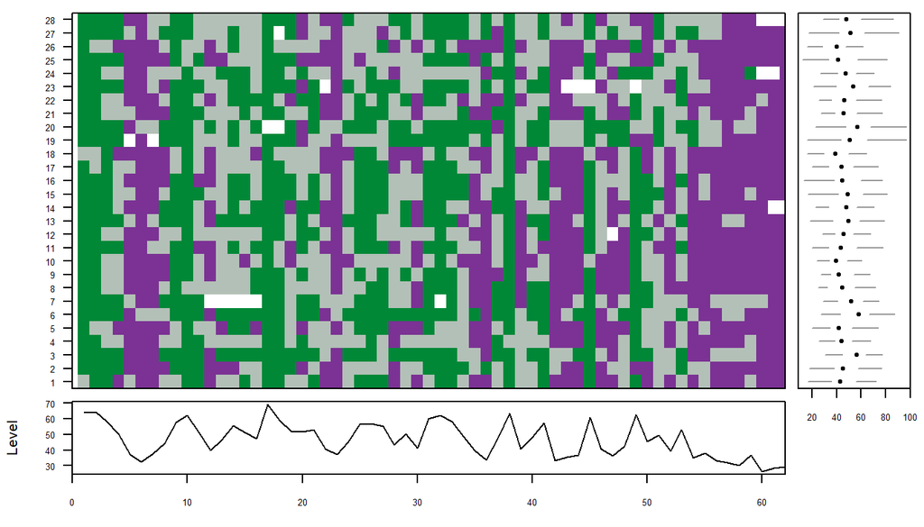

Daily ozone levels for 28 monitoring stations, Jul 1– Aug 31, 2006

```r
# Daily ozone levels for 28 monitoring stations, Jul 1– Aug 31, 2006.
mvtsplot(O3_wide, group = NULL, xtime = NULL, norm = c("global"),
         levels = 3, smooth.df = NULL, margin = TRUE, sort =NULL,
         main = "", palette = "PRGn", rowstat = "median", xlim,
         bottom.ylim = NULL, right.xlim=NULL, gcol = 3)
```

In the plot we use as color `PRGn` (default) from the `RColorBrewer` palettes. Here green indicates high values and purple indicates low values. Missing data are denoted by the color white. The bottom panel shows the overall median. Finally, on the right hand side panel, we can see the boxplots of the data in each time series.

- Moreover, we can check the basic statistics for ozone concentrations and make the histogram

```r
summary(NYdata$o8hrmax)
```

```
##    Min. 1st Qu.  Median    Mean 3rd Qu.    Max.    NA's
##   12.38   37.35   46.50   47.82   57.63  107.00      24
```

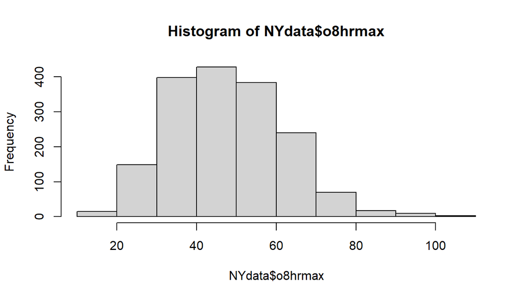

Histgram of ozone concentrations

```r
hist(NYdata$o8hrmax)
```

- We can visualize the relationships between the data using `GGally`, as we did in week 8.

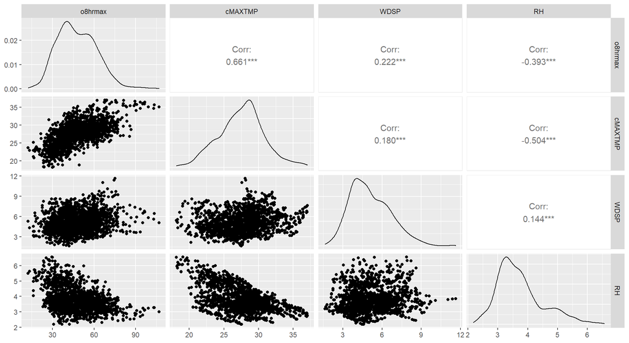

Figure 4. Plot of the correlation between variables in analysis

```r
ggpairs(NYdata[,7:10]) # print correlations between variables
```

- We print the table of the correlations between ozone and the three predictors using the package `corrr`:

```r
tab_cor = NYdata %>%
  select(o8hrmax, cMAXTMP, WDSP, RH) %>%
  correlate() %>%
  shave(upper = TRUE) %>%
  fashion(decimals = 2, na_print = "—")

tab_cor
```

```
##      term o8hrmax cMAXTMP WDSP RH
## 1 o8hrmax       —       —    —  —
## 2 cMAXTMP     .66       —    —  —
## 3    WDSP     .22     .18    —  —
## 4      RH    -.39    -.50  .14  —
```

- Now, we prepare data for spatial prediction and forecast (cross-validation)

```r
# define prediction sites for cross-validation (i.e. validation sites)
s <- c(8,11,12,14,18,21,24,28) # 8 stations

# deselected sites for predictions from dataset (training sites)
DataFit <- spT.subset(data=NYdata, var.name=c("s.index"), s=s, reverse=TRUE)
# Dim = 1240 (20stations*62days) * 11
# Note: spT.subset selects a subset of the dataset using the site numbers

# subset records without two days for forecast (30 and 31 August)
DataFit <- subset(DataFit, with(DataFit, !(Day %in% c(30, 31) & Month == 8))) # Dim = 1200 (20stations*60days) * 11

# select data for prediction (validation set)
DataValPred <- spT.subset(data=NYdata, var.name=c("s.index"), s=s)
# dim = 496 (8stations*62days) * 11

# remove days for forecast from validation set
DataValPred <- subset(DataValPred, with(DataValPred, !(Day %in% c(30, 31) & Month == 8))) # dim = 480 (8station*60days) * 11

# subset sites for forecast (validation set)
DataValFore <- spT.subset(data=NYdata, var.name=c("s.index"), s=c(8,11,12,14,18,21,24,28)) # dim = 496 (8stations*62days) * 11

# subset days for forecast within validation set (30 and 31 August for validation sites)
DataValFore <- subset(DataValFore, with(DataValFore, (Day %in% c(30, 31) & Month == 8))) # dim = 16 (8station*2days) * 11
```

- Plot the training and validation set (using `maps` package)

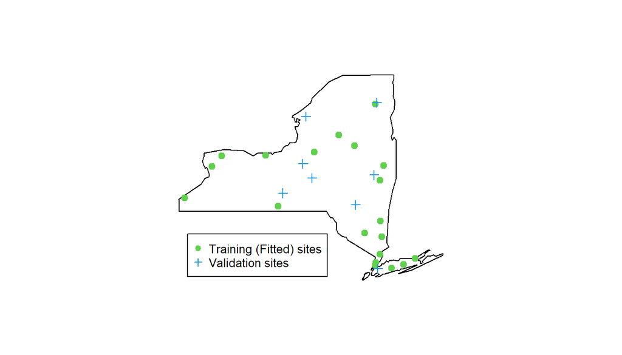

Map of the training and validation sites

```r
coords <- as.matrix(unique(cbind(DataFit[,2:3])))
pred.coords <- as.matrix(unique(cbind(DataValPred[,2:3])))

map(database="state",regions="new york")
points(coords, pch=19, col=3)
points(pred.coords, pch=3, col=4)
legend(x=-79.5,y=41.5,col=c(3,4),pch=c(19,3),cex=0.8,legend=c("Training (Fitted) sites","Validation sites"))
```

## Geostatistical spatio-temporal model

We now implement the spatio-temporal linear regression model for ozone concentrations using `spTimer`. Let:

- $\boldsymbol{Y}_t =(Y(\mathbf{s}_1,t), \dots, Y(\mathbf{s}_n,t))'$ be the observed data at location $\mathbf{s}$ in day $t$
- $\boldsymbol{O}_t =(O(\mathbf{s}_1,t), \dots, O(\mathbf{s}_n,t))'$ be the true value corresponding to $\boldsymbol{Y}_t$.

We use a hierarchical structure and we fit the following Bayesian model, with nugget effect model together with an independent Gaussian Process (GP) model at each time point:

$$\begin{equation*}
\begin{split}
%Y(\mathbf{s}_i,t) &= \boldsymbol{X}'(\mathbf{s}_i,t) \boldsymbol{\beta} + \boldsymbol{\eta}(\mathbf{s}_i,t)+\boldsymbol{\epsilon}(\mathbf{s}_i,t)
\boldsymbol{Y}_t &= \boldsymbol{O}_t +\boldsymbol{\epsilon}_t\\
\boldsymbol{O}_t &= \boldsymbol{X}_t \boldsymbol{\beta} + \boldsymbol{\eta}_t
\end{split}
\end{equation*}$$

where:

- $\boldsymbol{X}_t$ are the covariate values and $\boldsymbol{\beta}$ are the regression coefficients
- $\boldsymbol{\eta}_t=(\eta(\mathbf{s}_1,t), \dots, \eta(\mathbf{s}_n,t))'$ are the spatio-temporal random effects, assumed to follow $N(\mathbf{0}, \Sigma_{\eta})$ independently in time, where $\Sigma_{\eta}=\sigma_{\eta}^{2} S_{\eta}$, here $\sigma_{\eta}^2$ is the site invariant spatial variance and $S_{\eta}$ is the spatial correlation matrix.
- $\boldsymbol{\epsilon}_t=(\epsilon(\mathbf{s}_1,t), \dots, \epsilon(\mathbf{s}_n,t))'$ is the nugget effect or the pure error term, independent in space and time.

```r
set.seed(11)
post.gp <- spT.Gibbs(formula=o8hrmax ~ cMAXTMP+WDSP+RH,
                     data=DataFit, model="GP",
                     coords=~Longitude+Latitude,
                     scale.transform="SQRT",
        spatial.decay=spT.decay(distribution=Gamm(2,1),tuning=0.1),
        nItr = 15000, nBurn = 5000,report = 1,
        distance.method = "geodetic:km", cov.fnc = "exponential")
```

```
##
##  Output: GP models
## ---------------------------------------------------------------
##  Sampled: 15000 of 15000, 100.00%.
##  Batch Acceptance Rate (phi): 32.06%
##  Checking Parameters:
##    phi: 0.0089, sig2eps: 0.0124, sig2eta: 0.6886
##    beta[1]: 3.6569   beta[2]: 0.1435   beta[3]: 0.0630   beta[4]: -0.2499
## ---------------------------------------------------------------
## ##
## # nBurn =  5000 , Iterations =  15000 .
## # Overall Acceptance Rate (phi) =  32.06 %
## ##
## ##
## # Elapsed time: 10.35 Sec.
## ##
##
## # Model: GP
```

- Perform diagnostic

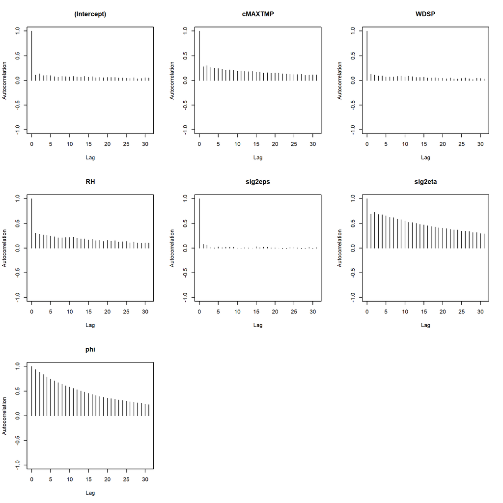

```r
# plot(post.gp)

# with coda
autocorr.plot(as.mcmc(post.gp))
```

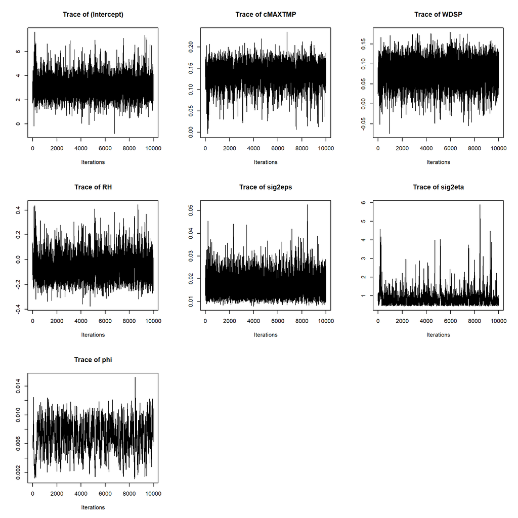

```r
plot(as.mcmc(post.gp), auto.layout=TRUE, density=FALSE)
```

```r
# with mcmcplots
# mcmcplot(post.gp)
```

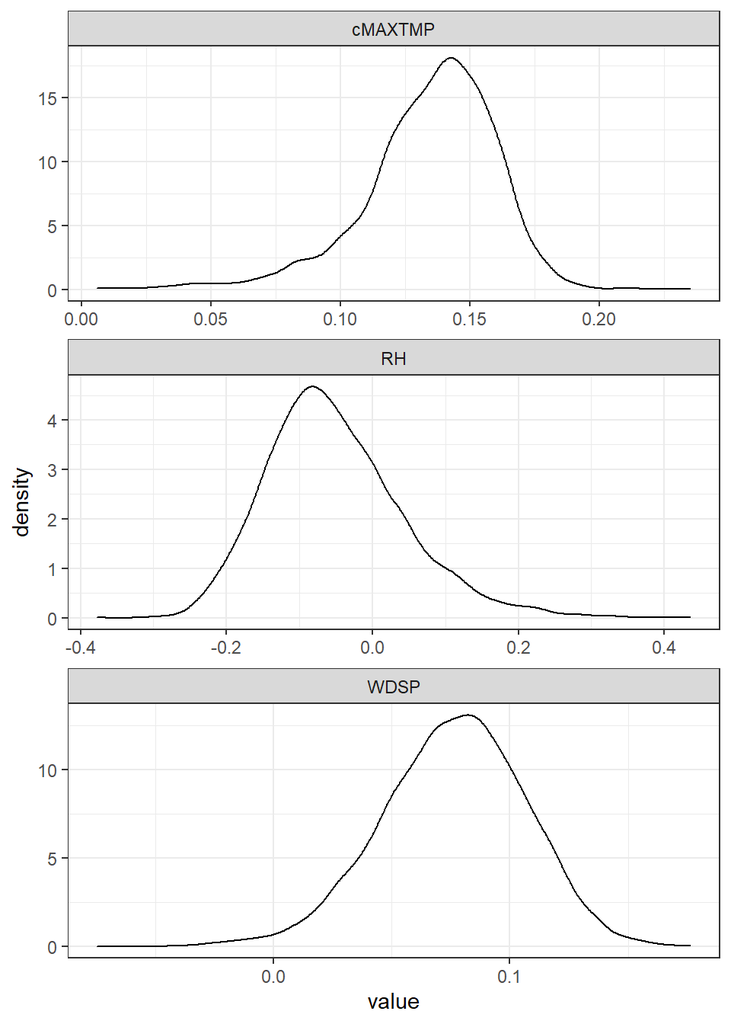

```r
# with ggmcmc
ggsamples <- ggs(as.mcmc(post.gp))
ggsamples %>% filter(Parameter == c("cMAXTMP","WDSP","RH")) %>%
  ggs_density() + theme_bw()
```

- Obtain the parameter estimates from the MCMC samples

```r
print(post.gp)
```

```
## -----------------------------------------------------
## Model: GP
## Call: o8hrmax ~ cMAXTMP + WDSP + RH
## Iterations: 15000
## nBurn: 5000
## Acceptance rate for phi (%): 32.06
## -----------------------------------------------------
##         Goodness.of.fit Penalty   PMCC
## values:          254.81  631.06 885.87
## -----------------------------------------------------
## Computation time: 10.35  - Sec.
```

```r
summary(post.gp)
```

```
## -----------------------------------------------------
## Model: GP
## Call: o8hrmax ~ cMAXTMP + WDSP + RH
## Iterations: 15000
## nBurn: 5000
## Acceptance rate for phi (%): 32.06
## -----------------------------------------------------
##         Goodness.of.fit Penalty   PMCC
## values:          254.81  631.06 885.87
## -----------------------------------------------------
## Computation time: 10.35  - Sec.
## -----------------------------------------------------
## Parameters:
##                Mean  Median     SD Low2.5p Up97.5p
## (Intercept)  3.1425  3.0907 0.8208  1.6921  4.9758
## cMAXTMP      0.1349  0.1379 0.0252  0.0755  0.1760
## WDSP         0.0765  0.0779 0.0304  0.0125  0.1321
## RH          -0.0523 -0.0637 0.0968 -0.2125  0.1748
## sig2eps      0.0166  0.0160 0.0042  0.0104  0.0267
## sig2eta      0.8161  0.6906 0.4039  0.4808  1.9642
## phi          0.0069  0.0072 0.0022  0.0022  0.0106
## -----------------------------------------------------
```

The parameter estimates show that the predictors, except relative humidity, have an impact on ozone concentrations, since the 95% credible intervals of the regression coefficients for wind and max temperature do not contain zero. The posterior estimate of the spatial decay parameter $\phi$ is approximately 0.007 implies an effective range of $\sim$ 428 kilometers (obtained as $3/\phi$).

- Obtain the PMCC

```r
post.gp$PMCC
```

```
##         Goodness.of.fit Penalty   PMCC
## values:          254.81  631.06 885.87
```

### Spatial prediction for the GP model

```r
set.seed(11)
pred.gp <- predict(post.gp, newdata=DataValPred,
                   newcoords=~Longitude+Latitude)
```

```
##
##  Prediction: GP models
## #
## # Tolerance Limit (unit): 2
## # Location distances are alright
## #
## -------------------------------------------------
##   Sampled: 1000 of 10000, 10.00%
## -------------------------------------------------
## -------------------------------------------------
##   Sampled: 2000 of 10000, 20.00%
## -------------------------------------------------
## -------------------------------------------------
##   Sampled: 3000 of 10000, 30.00%
## -------------------------------------------------
## -------------------------------------------------
##   Sampled: 4000 of 10000, 40.00%
## -------------------------------------------------
## -------------------------------------------------
##   Sampled: 5000 of 10000, 50.00%
## -------------------------------------------------
## -------------------------------------------------
##   Sampled: 6000 of 10000, 60.00%
## -------------------------------------------------
## -------------------------------------------------
##   Sampled: 7000 of 10000, 70.00%
## -------------------------------------------------
## -------------------------------------------------
##   Sampled: 8000 of 10000, 80.00%
## -------------------------------------------------
## -------------------------------------------------
##   Sampled: 9000 of 10000, 90.00%
## -------------------------------------------------
## -------------------------------------------------
##   Sampled: 10000 of 10000, 100.00%
## -------------------------------------------------
## ##
## # Predicted samples and summary statistics are given.
## # nBurn =  5000 . Iterations =  15000 .
## ##
## ##
## # Elapsed time: 5.47 Sec.
## ##
```

```r
print(pred.gp)
```

```
## --------------------------------------
## Spatial prediction with Model: GP
## Covariance function: exponential
## Distance method: geodetic:km
## Computation time:  5.47  - Sec.
## --------------------------------------
```

```r
names(pred.gp)
```

```
##  [1] "pred.samples"         "pred.coords"          "distance.method"
##  [4] "Distance.matrix.pred" "cov.fnc"              "predN"
##  [7] "Mean"                 "Median"               "SD"
## [10] "Low"                  "Up"                   "computation.time"
## [13] "model"                "type"
```

### Validation criteria

```r
spT.validation(DataValPred$o8hrmax,c(pred.gp$Median))
```

```
##     MSE    RMSE     MAE    MAPE    BIAS   rBIAS   rMSEP
## 43.1934  6.5722  5.0762 11.8615  0.6532  0.0140  0.2613
```

### Temporal prediction

Here the forecast for two-step ahead (i.e., in day 61 and 62) in the unobserved locations using output from spT.Gibbs

```r
set.seed(11)
fore.gp <- predict(post.gp, newdata=DataValFore,
                   newcoords=~Longitude+Latitude,
                   type="temporal", foreStep=2)
```

```
##
##  Forecast: GP models
## -------------------------------------------------
##   Sampled: 1000 of 10000, 10.00%
## -------------------------------------------------
## -------------------------------------------------
##   Sampled: 2000 of 10000, 20.00%
## -------------------------------------------------
## -------------------------------------------------
##   Sampled: 3000 of 10000, 30.00%
## -------------------------------------------------
## -------------------------------------------------
##   Sampled: 4000 of 10000, 40.00%
## -------------------------------------------------
## -------------------------------------------------
##   Sampled: 5000 of 10000, 50.00%
## -------------------------------------------------
## -------------------------------------------------
##   Sampled: 6000 of 10000, 60.00%
## -------------------------------------------------
## -------------------------------------------------
##   Sampled: 7000 of 10000, 70.00%
## -------------------------------------------------
## -------------------------------------------------
##   Sampled: 8000 of 10000, 80.00%
## -------------------------------------------------
## -------------------------------------------------
##   Sampled: 9000 of 10000, 90.00%
## -------------------------------------------------
## -------------------------------------------------
##   Sampled: 10000 of 10000, 100.00%
## -------------------------------------------------
## ##
## # Forecast samples and summary statistics are given.
## # nBurn =  0 . Iterations =  10000 .
## ##
## ##
## # Elapsed time: 1.25 Sec.
## ##
```

```r
print(fore.gp)
```

```
## --------------------------------------
## Temporal prediction/forecast with Model: GP
## Covariance function: exponential
## Distance method: geodetic:km
## Computation time:  1.25  - Sec.
## --------------------------------------
```

- Forecast validations

```r
spT.validation(DataValFore$o8hrmax,c(fore.gp$Median))
```

```
##     MSE    RMSE     MAE    MAPE    BIAS   rBIAS   rMSEP
## 26.4641  5.1443  4.7946 16.6146  4.3432  0.1452  1.2160
```

```r
# Inspect the two forecast (posterior median) for the validation sites
fore.gp$Median
```

```
##          [,1]     [,2]     [,3]     [,4]     [,5]     [,6]     [,7]     [,8]
## [1,] 33.79106 33.01709 33.55517 33.01183 34.38119 35.48211 34.36589 31.21924
## [2,] 35.23672 34.67816 33.71832 33.33453 34.40710 34.47298 34.03506 32.05243
```

## Prediction on the grid

- We now perform prediction on a grid to obtain a continuous surface of ozone concentrations. To do so, we read in `NYgrid`, which contains a total of 6200 rows for 62 days of observations for 10x10 = 100 grid points. Then we re-run the GP model for all the points in the dataset (i.e. `NYdata`) and make prediction on the grid.

```r
data(NYgrid)
set.seed(11)

# GP regression
# (for demonstration, we us here a low number of iterations)
post.gp2 <- spT.Gibbs(formula=o8hrmax ~cMAXTMP+WDSP+RH,
        data=NYdata, model="GP",
        coords=~Longitude+Latitude, nItr=5000, nBurn=1000,
        scale.transform="SQRT",
        spatial.decay=spT.decay(distribution=Gamm(2,1),tuning=0.1))
```

```
##
##  Output: GP models
## ---------------------------------------------------------------
##  Sampled: 5000 of 5000, 100.00%.
##  Batch Acceptance Rate (phi): 30.19%
##  Checking Parameters:
##    phi: 0.0142, sig2eps: 0.0196, sig2eta: 0.7475
##    beta[1]: 1.8909   beta[2]: 0.1714   beta[3]: 0.1157   beta[4]: -0.0728
## ---------------------------------------------------------------
## ##
## # nBurn =  1000 , Iterations =  5000 .
## # Overall Acceptance Rate (phi) =  30.18 %
## ##
## ##
## # Elapsed time: 5.53 Sec.
## ##
##
## # Model: GP
```

```r
# Prediction
set.seed(11)
grid.pred <- predict(post.gp2, newdata=NYgrid,
                     newcoords=~Longitude+Latitude)
```

```
##
##  Prediction: GP models
## #
## # Tolerance Limit (unit): 2
## # Location distances are alright
## #
## -------------------------------------------------
##   Sampled: 400 of 4000, 10.00%
## -------------------------------------------------
## -------------------------------------------------
##   Sampled: 800 of 4000, 20.00%
## -------------------------------------------------
## -------------------------------------------------
##   Sampled: 1200 of 4000, 30.00%
## -------------------------------------------------
## -------------------------------------------------
##   Sampled: 1600 of 4000, 40.00%
## -------------------------------------------------
## -------------------------------------------------
##   Sampled: 2000 of 4000, 50.00%
## -------------------------------------------------
## -------------------------------------------------
##   Sampled: 2400 of 4000, 60.00%
## -------------------------------------------------
## -------------------------------------------------
##   Sampled: 2800 of 4000, 70.00%
## -------------------------------------------------
## -------------------------------------------------
##   Sampled: 3200 of 4000, 80.00%
## -------------------------------------------------
## -------------------------------------------------
##   Sampled: 3600 of 4000, 90.00%
## -------------------------------------------------
## -------------------------------------------------
##   Sampled: 4000 of 4000, 100.00%
## -------------------------------------------------
## ##
## # Predicted samples and summary statistics are given.
## # nBurn =  1000 . Iterations =  5000 .
## ##
## ##
## # Elapsed time: 34.41 Sec.
## ##
```

- Finally, we plot the spatial predictions (code by the authors is provided https://github.com/cran/spTimer/blob/master/demo/nyExample.R)

```r
# this function is created by spTimer's authors and
# it used to delete values outside NY
fnc.delete.map.XYZ <- function(xyz){
    x<-xyz$x; y<-xyz$y; z<-xyz$z
    xy <- expand.grid(x, y)
    eus <- (map.where(database="state", x=xy[,1], y=xy[,2]))
    dummy <- rep(0, length(xy[,1]))
    eastUS <- NULL
    eastUS <- data.frame(lon=xy[,1],lat=xy[,2],state=eus,dummy=dummy)
    eastUS[!is.na(eastUS[,3]),4]<-1
    eastUS[eastUS[,3]=="pennsylvania" & !is.na(eastUS[,3]),4]<-0
    eastUS[eastUS[,3]=="new jersey" & !is.na(eastUS[,3]),4]<-0
    eastUS[eastUS[,3]=="connecticut" & !is.na(eastUS[,3]),4]<-0
    eastUS[eastUS[,3]=="massachusetts:main" & !is.na(eastUS[,3]),4]<-0
    eastUS[eastUS[,3]=="new hampshire" & !is.na(eastUS[,3]),4]<-0
    eastUS[eastUS[,3]=="vermont" & !is.na(eastUS[,3]),4]<-0
    a <- eastUS[, 4]
    z <- as.vector(xyz$z)
    z[!a] <- NA
    z <- matrix(z, nrow = length(xyz$x))
      xyz$z <- z
      xyz
}
```

```r
coords <- unique(NYdata[,c("Longitude","Latitude")])
grid.coords <- unique(NYgrid[,c("Longitude","Latitude")])
true.val <- matrix(NYdata$o8hrmax,62,28) # 62 time points, 28 stations
grid.val <- matrix(grid.pred$Median,62,dim(grid.coords)[[1]])
grid.sd <- matrix(grid.pred$SD,62,dim(grid.coords)[[1]])

surfplot<-function(day=60, val, ...) # three dots are called ellipsis
{
    z <- val
    surf <- cbind(grid.coords, z[day,])
    surf <- mba.surf(surf,200,200)$xyz # from MBA package
    surf <- fnc.delete.map.XYZ(xyz=surf)
    image.plot(surf, xlab="Longitude",ylab="Latitude",axes=F, ...) # from fields package
    contour(surf,nlevels=10,lty=3,add=T)
    map(database="state",regions="new york",add=T) # add contour NY from maps package
    axis(1);axis(2)
}
```

- Now we use the functions written by the authors to obtain the spatially interpolated plots of the daily maximum 8-hour ozone concentration levels (posterior median) and its standard deviation. Here we plot them for the 29 August, 2006 (i.e. day 60)

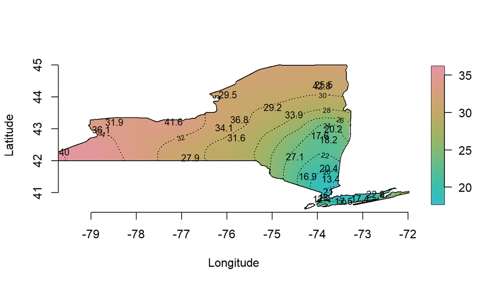

Spatial interpolation of the daily maximum 8-hour ozone concentrations

```r
# prediction for day 60
# Actual observations are superimposed
day <- 60
surfplot(day, val=grid.val, col = rainbow_hcl(100, start = 200, end = 0))
text(coords,labels=round(true.val[day,],1), cex=0.8,col=1)
```

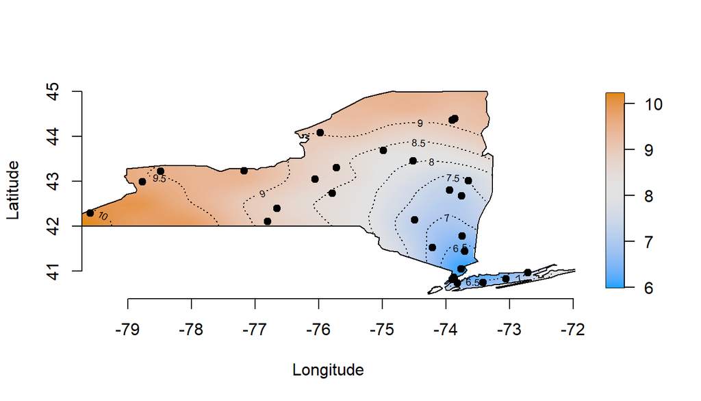

Standard deviation of ozone concentrations

```r
# Standard deviation for day 60
# Actual location of the monitoring stations are superimposed
day <- 60
surfplot(day, val=grid.sd, col = diverge_hcl(100, h = c(246, 40), c = 96, l = c(65, 90)))
points(coords,pch=19,cex=1,col=1)
```

```r
# Note that the hcl function from colorspace package creates a vector of R colours with the given hue, chroma and luminance values. Here in diverge_hcl function: h refers to the hue value, while c and l refer to the chroma value and luminance in the HCL color description
```

# References

Bakar, Khandoker Shuvo, and Sujit K. Sahu. 2015. “spTimer: Spatio-Temporal Bayesian Modeling Using R.” *Journal of Statistical Software* 63 (15): 1–32. http://www.jstatsoft.org/v63/i15.